# Tabulizer and Digitizer examples

KEA - SPA

6/5/2018

This slide is hosted at RPubs

## Rrrresources

FMI on the nitty gritty of R and general tips/tricks:

- [YaRrr! The Pirate’s Guide to R](https://bookdown.org/ndphillips/YaRrr/where-did-this-book-come-from.html)
- [Grolemund and Wickham](http://r4ds.had.co.nz/intro.html)
- [Jenny Bryan’s Stat 545 course](http://stat545.com/topics.html)
- [Julie Lowndes](http://jules32.github.io/2016-07-12-Oxford/R_RStudio/)
- [R for CEPF intro slides](http://rpubs.com/chwchang/392088)

A humorous (and insightful) take comes from seasoned python programmers who feel very *Arrrgh* about R

- [John D Cook](https://www.johndcook.com/blog/r_language_for_programmers/)
- [aRrgh: an angry guide to R](http://arrgh.tim-smith.us/)

Let us know if you’d like more resources!

### Issues with installation

Installing `tabulizer` can be difficult due to underlying problems with `rJava` that can be frustratingly opaque and difficult to diagnose. Here are my notes for how I managed to get `rJava` and subsequently, `tabulizer` to install properly.

1. It looks like I can’t get `tabulizer` to install because of [pointing issues](https://github.com/ropensci/tabulizer/issues/42) and/or version issues for the Java distribution that `rJava` is trying to point to.
   1. Needs to be Java 1.7 or 1.8 on up, but either on the `tabulizer` or `tabula` (`tabula` is the Java library that `tabulizer` imports into R) end, it seems like it gets rJava to default point to v 1.6.x if it is on the machine.
2. Open terminal and type the following:
   1. `MacBook-Pro-5:~ Char$ export JAVA_HOME=\x60/usr/libexec/java_home -v 1.8\x60`
   2. `MacBook-Pro-5:~ Char$ export LD_LIBRARY_PATH=$JAVA_HOME/jre/lib/server`
   3. `MacBook-Pro-5:~ Char$ env`
3. From the env command, you should now see:
   1. `PWD=/Users/Char`
   2. `JAVA_HOME=/Library/Java/JavaVirtualMachines/jdk1.8.0_151.jdk/Contents/Home`
   3. `LANG=en_US.UTF-8`
4. In terminal call `open -a RStudio`
5. In Rstudio, call:

```r
# install.packages(rJava)
library(rJava)
                .jinit()
                .jcall(“java/lang/System”, “S”, “getProperty”, “java.runtime.version”)
```

### Examples of using `tabulizer` and `digitize`

- [Digitize examples](https://github.com/tpoisot/digitize)
- [Tabulizer examples](https://github.com/ropensci/tabulizer)

## Importing an example figure

Below, we will use the `googledrive` package to import the file `Galetti1A.png` from our team drive. We will subsequently call `digitize` to extract information from the barchart.

```r
###===========================================================================
### Importing and downloading figure from Google Drive Team Folder
###===========================================================================
galetti1A_loc <- drive_get(id="10CXIOQAIIoC8Z9K_xjx97PwB63XEU-YR", team_drive = "CoharvestSRE") # Location of Galetti1A figure
galetti1A_fig <- drive_download(file=galetti1A_loc, path="~/GoogleDrive/Rscripts/SRE_coharvest/Galetti1A.png", overwrite=TRUE) # Downloading the figure to your local folder (note that you can skip these two steps and just directly point and click download instead or work from your local machine)

###===========================================================================
### Digitizing plot
###===========================================================================

galetti1A <- digitize::digitize(image_filename=galetti1A_fig$local_path) # Note that you could instead directly specify a local path and bypass the two steps above. Then it would be:
# galetti1A <- digitize::digitize(image_filename="~/GoogleDrive/Rscripts/SRE_coharvest/Galetti1A.png")

# save(galetti1A, file="~/GoogleDrive/Rscripts/SRE_coharvest/galetti1Adigitize.RData") # save the output to a serialized file

dev.copy(png,"~/Downloads/galetti1A-digitized.png", width=4, height=3, units="in", res=120, bg="transparent") # store the output to file; this is different from the usual routine because the digitizer package needs unencumbered access to the "Plots" tab in RStudio (not sure how it works in base R)
dev.off()
```

We can inspect the output by displaying it here:

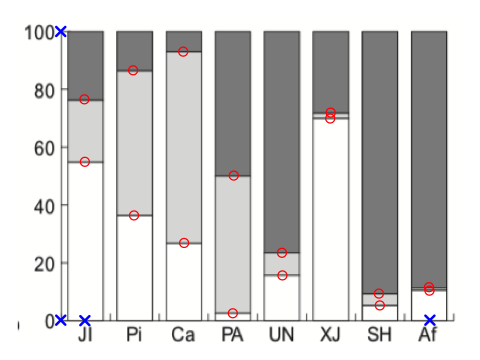

galetti1A

```r
###===========================================================================
### Extracting data
###===========================================================================
attach("~/GoogleDrive/Rscripts/SRE_coharvest/galetti1Adigitize.RData")
galetti1A # we don't care about the X values; these are just dummy values.
```

```
##            x         y
## 1  1.0000000 54.855196
## 2  0.9905914 76.490630
## 3  1.9973118 36.286201
## 4  1.9784946 86.541738
## 5  3.0134409 26.746167
## 6  2.9946237 93.015332
## 7  4.0013441  2.385009
## 8  4.0201613 50.085179
## 9  5.0080645 15.502555
## 10 4.9986559 23.339012
## 11 5.9771505 69.846678
## 12 5.9865591 71.890971
## 13 6.9838710  5.110733
## 14 6.9650538  9.199319
## 15 7.9905914 10.221465
## 16 7.9811828 11.413969
```

```r
### 1: Pulling the y-column out
galetti1A_data <- galetti1A$y # we only care about the y-axis as this is a barplot with categories on the X

### 2: Pushing these values into a data.frame
galetti1A_df <- data.frame(Intact=galetti1A_data[c(TRUE,FALSE)],
                           Rodents=galetti1A_data[c(FALSE,TRUE)]-galetti1A_data[c(TRUE,FALSE)],
                           Insects=100-galetti1A_data[c(FALSE,TRUE)])
rownames(galetti1A_df) <- c("JI","Pi","Ca","PA","UN","XJ","SH","Af")

### 3: Displaying the table in a nice format (note that you need to run install.packages("htmlTable"))
htmlTable::htmlTable( round(galetti1A_df,1), # round to 1 decimal point, also see ?signif
                      rowlabel="Sites")
```

| Sites | Intact | Rodents | Insects |
| --- | --- | --- | --- |
| JI | 54.9 | 21.6 | 23.5 |
| Pi | 36.3 | 50.3 | 13.5 |
| Ca | 26.7 | 66.3 | 7 |
| PA | 2.4 | 47.7 | 49.9 |
| UN | 15.5 | 7.8 | 76.7 |
| XJ | 69.8 | 2 | 28.1 |
| SH | 5.1 | 4.1 | 90.8 |
| Af | 10.2 | 1.2 | 88.6 |

My guess from this type of data is what is ultimately useful is:

- What is dispersed (galetti1B; black cells)?
- The relationship between hunting pressure and/or rodent density and the percentage of seeds that are predated (`preyed upon by rodents` in Galetti’s paper) versus dispersed (1B).

## Tabulizer example: Peres *et al.*, Brazil nut harvest

In **Table S1**, Carlos Peres and co-authors present information on the density and population structure of Brazil nut populations.

Steps:

- Import the PDF from the Google Drive Team folder
- Use tabulizer to import the table
- Perform cleaning to get the table into a usable format

```r
###===========================================================================
### Importing table from PDF
###===========================================================================

peresPDF <- drive_find(pattern="Peres-BrazilNut-Science", team_drive="CoharvestSRE")
peresPDFurl <- drive_link(peresPDF)
# peresS1 <- tabulizer::extract_tables(file=peresPDFurl, pages=10) # uffda, sadly does not quite work. Will have to spend some time troubleshooting
peresS1 <- tabulizer::extract_tables(file="/Volumes/GoogleDrive/Team Drives/CoharvestSRE/Readings/Parameters/Peres-BrazilNut-Science.full.pdf", pages=10)

save(peresS1, file="~/GoogleDrive/Rscripts/SRE_coharvest/peresS1.RData")
```

```r
attach("~/GoogleDrive/Rscripts/SRE_coharvest/peresS1.RData")
###===========================================================================
### Cleaning table
###===========================================================================
head(peresS1[[1]]) # wow it looks AWFUL!
```

```
##      [,1]
## [1,] "Table S1.  Brazil nut tree (Bertholletia excelsa) populations examined in this study.  Site numbers refer to those show"
## [2,] "corresponds to the aggregate area of forest plots and/or transect strip-width censused at each site.  NA = data not avai"
## [3,] ""
## [4,] ""
## [5,] "Site Latitude, Area sampled Density Mean ± SE s* a % No. of tree"
## [6,] "No. Site locality State, Country Longitude (ha) (ind. ha–1) DBH (cm) Juveniles sampled"
```

```r
peresS1list <- peresS1[[1]][7:38,]
peresS1list <- lapply(peresS1list, function(x) {unlist(strsplit(x," "))})

peres_entries <- unlist(lapply(peresS1list, length)) # the table import was wonky so it is incorrectly splitting along newlines
peres_rows <- which(peres_entries > 3)

peresS1df <- NULL # run a for loop below to extract data from the tabulizer object
for (i in 1:length(peres_rows)) {
  peresS1df <- rbind(peresS1df, tail(peresS1list[[peres_rows[i]]], 10))
}

peresS1df <- data.frame(peresS1df, stringsAsFactors = FALSE) # convert output from matrix to data.frame format
names(peresS1df) <- c("Latitude","Longitude","AreaHectares","Density-treeHA-1","MeanDBH","pm","SE_DBH","CumS*","PercentJuve","NoTreeSampled")
peresS1df[c(3:5,7:10)] <- apply(peresS1df[c(3:5,7:10)], 2, as.numeric) # convert several columns to numeric class
peresS1df$HuntIntensity <- c("U","U","P","L","L","P","P","L","M","L","M",rep("U",2),rep("L",6),rep("M",2),"U","M") # argh, this column didn't import so we get to hand impute...lovely

###===========================================================================
### Displaying table
###===========================================================================
htmlTable::htmlTable(peresS1df, rnames=c("Pinkaiti","Kranure","Saraca","Maraba","Tapajos","Alto Cajar","Iratapuru","Aventura","Ussicanta","Lago Ciputuba","Amana","Rio Cristalino","Claudia","Nova Esperanca","Colocacao Tucuma","Colocacao Rio","Encontro","Oculto","Limon","El Tigre","El Sena","Alter do Chao","Rio Ouro Preto"), rowlabel="Sites")
```

| Sites | Latitude | Longitude | AreaHectares | Density-treeHA-1 | MeanDBH | pm | SE_DBH | CumS* | PercentJuve | NoTreeSampled | HuntIntensity |
| --- | --- | --- | --- | --- | --- | --- | --- | --- | --- | --- | --- |
| Pinkaiti | 7°46’S, | 51°57’W | 60 | 3.3 | 72.6 | ± | 3.8 | 1.886 | 43.3 | 224 | U |
| Kranure | 7°49’S, | 51°55’W | 16 | 3.4 | 65.7 | ± | 7.6 | 1.92 | 52.5 | 40 | U |
| Saraca | 1°45’S, | 56°30’W | 769 | 1.5 | 134.8 | ± | 1.4 | -1.1 | 1.6 | 1165 | P |
| Maraba | 5°12’S, | 49°06’W | 9 | 4.3 | 119.4 | ± | 11.7 | 1.572 | 33.3 | 39 | L |
| Tapajos | 3°55’S, | 55°28’W | 100 | 0.7 | 73.8 | ± | 2.9 | 1.438 | 35.7 | 269 | L |
| Alto Cajar | 0°20’S, | 51°43’W | 23 | 12 | 156.4 | ± | 2.9 | -1.85 | 0.7 | 272 | P |
| Iratapuru | 0°03’N, | 52°30’W | 25 | 9.4 | 154.1 | ± | 3 | -1.779 | 0.9 | 230 | P |
| Aventura | 4°19’S, | 62°30’W | 25.8 | 6.8 | 102.3 | ± | 4.3 | 0.315 | 24.6 | 122 | L |
| Ussicanta | 4°21’S, | 62°35’W | 15.4 | 8.5 | 133.5 | ± | 3.04 | -2.582 | 3.8 | 132 | M |
| Lago Ciputuba | 5°48’S, | 60°13’W | 114 | 1.8 | 116.6 | ± | 3.91 | 0.348 | 22.4 | 201 | L |
| Amana | 2°21’S, | 64°45’W | 50 | 1.4 | 123.5 | ± | 4.1 | -1.891 | 5.3 | 76 | M |
| Rio Cristalino | 9°28’S, | 55°55’W | 64 | 4.9 | 90.7 | ± | 6.1 | 1.691 | 40.7 | 113 | U |
| Claudia | 11°30’S, | 54°48’W | 35 | 3.6 | 71 | ± | 4.5 |  | 31.2 | 125 | U |
| Nova Esperanca | 10°40’S, | 68°30’W | 51 | 3.1 | 73.9 | ± | 4.3 | 1.809 | 47.2 | 161 | L |
| Colocacao Tucuma | 10°51’S, | 68°44’W | 184.5 | 1.4 | 108 | ± | 2.4 | -0.783 | 12.2 | 255 | L |
| Colocacao Rio | 10°47’S, | 68°40’W | 378 | 1.4 | 89.8 | ± | 1.9 | 0.44 | 32.4 | 568 | L |
| Encontro | 10°43’S, | 68°50’W | 211 | 1.4 | 91.4 | ± | 2.5 | -1.029 | 25.1 | 295 | L |
| Oculto | 12°39’S, | 68°56’W | 925 | 0.7 | 109.9 | ± | 1.5 | -0.974 | 10.9 | 613 | L |
| Limon | 12°32’S, | 68°52’W | 1350 | 0.1 | 108.2 | ± | 2.9 | -0.587 | 10.6 | 160 | L |
| El Tigre | 11°30’S; | 67°15’W | 12 | 1.7 | 102.1 | ± | 3 | 0.162 | 25 | 20 | M |
| El Sena | 10°59’S, | 65°43’W | 7 | 3.3 | 111.3 | ± | 3.7 | 0.401 | 21.7 | 23 | M |
| Alter do Chao | 2°33’S, | 54°53’W | 3 | 23 | 44.9 | ± | 5.3 | 2.509 | 75.6 | 78 | U |
| Rio Ouro Preto | 10°45’S, | 65°30’W | 12 | 2 | 127.7 | ± | 7.3 | -1.917 | 4.5 | 22 | M |

In this case, what we likely care about is:

- Do they specify what “hunt intensity” means? Is it a measure of how many seeds were removed?
- Is there information on agouti density along with the hunt intensity and juvenile composition data?

To be honest, however, this data set is related but a bit orthogonal IMO to the type of data that we would need.